# DATA 607 Assignment 5: Tidying and Transforming Data

Peter

9/26/2020

# Exercise

The chart below describes arrival delays for two airlines across five destinations. Your task is to: (1) Create a .CSV file (or optionally, a MySQL database!) that includes all of the information above. You’re encouraged to use a “wide” structure similar to how the information appears above, so that you can practice tidying and transformations as described below. (2) Read the information from your .CSV file into R, and use tidyr and dplyr as needed to tidy and transform your data. (3) Perform analysis to compare the arrival delays for the two airlines. (4) Your code should be in an R Markdown file, posted to rpubs.com, and should include narrative descriptions of your data cleanup work, analysis, and conclusions. Please include in your homework submission:  The URL to the .Rmd file in your GitHub repository. and  The URL for your rpubs.com web page.

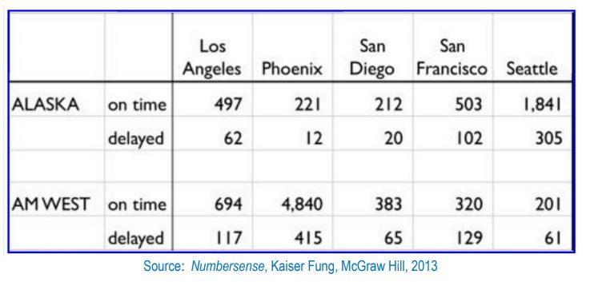

# Solution :

### Read the csv file from GitHub with the table data and replace empty values with NA

```r
csv <- read.csv("https://raw.githubusercontent.com/petferns/607-week5/master/untidy.csv", na.strings = c("", "NA"))
head(csv)
```

```
##       ï..       X Los.Angeles Phoenix San.Diego San.Francisco Seattle
## 1  ALASKA on time         497     221       212           503    1841
## 2    <NA> delayed          62      12        20           102     305
## 3    <NA>    <NA>          NA      NA        NA            NA      NA
## 4 AM WEST on time         694    4840       383           320     201
## 5    <NA> delayed         117     415        65           129      61
```

#### We see a empty row at row number 3, all variables value are NA so we don’t need this row, lets neglect it.

```r
csv <- csv[!apply(is.na(csv[1:7]),1,all), ]
```

### Let us rename the 1st and 2nd column

```r
# Renaming the first column to Airline and second to Status
names(csv)[1] <- "Airline"
names(csv)[2] <- "Status"
head(csv)
```

```
##   Airline  Status Los.Angeles Phoenix San.Diego San.Francisco Seattle
## 1  ALASKA on time         497     221       212           503    1841
## 2    <NA> delayed          62      12        20           102     305
## 4 AM WEST on time         694    4840       383           320     201
## 5    <NA> delayed         117     415        65           129      61
```

#### We need to replace the NA in row 2 with **ALASKA** and replace NA in row 4 with **AM WEST** assuming the row is for previous Airline

```r
for(i in 2:nrow(csv)) {

  if(is.na(csv$Airline[i])){
    csv$Airline[i] <- csv$Airline[i-1]
  }
}
```

#### Let us now apply gather function to make the wide structure to long with key value pair as City and Count.

```r
wide_to_long <- gather(csv, "City", "Count", 3:7)
head(wide_to_long)
```

```
##   Airline  Status        City Count
## 1  ALASKA on time Los.Angeles   497
## 2  ALASKA delayed Los.Angeles    62
## 3 AM WEST on time Los.Angeles   694
## 4 AM WEST delayed Los.Angeles   117
## 5  ALASKA on time     Phoenix   221
## 6  ALASKA delayed     Phoenix    12
```

#### Let us now apply spread function on Status column so that each distinct value becomes a column

```r
transformed <- spread(wide_to_long,Status,Count)
datatable(transformed, extensions = 'Scroller', options = list(scrollY = 200, scroller = TRUE ))
```

|  | Airline | City | delayed | on time |
| --- | --- | --- | --- | --- |
| 1 | ALASKA | Los.Angeles | 62 | 497 |
| 2 | ALASKA | Phoenix | 12 | 221 |
| 3 | ALASKA | San.Diego | 20 | 212 |
| 4 | ALASKA | San.Francisco | 102 | 503 |
| 5 | ALASKA | Seattle | 305 | 1841 |
| 6 | AM WEST | Los.Angeles | 117 | 694 |
| 7 | AM WEST | Phoenix | 415 | 4840 |
| 8 | AM WEST | San.Diego | 65 | 383 |
| 9 | AM WEST | San.Francisco | 129 | 320 |
| 10 | AM WEST | Seattle | 61 | 201 |

#### Calculate the overall ontime performance and compare over plot

```r
overall_ontime <- transformed %>% group_by(Airline) %>% summarize(avg_ontime = mean(`on time`))
head(overall_ontime)
```

```
## # A tibble: 2 x 2
##   Airline avg_ontime
##   <chr>        <dbl>
## 1 ALASKA        655.
## 2 AM WEST      1288.
```

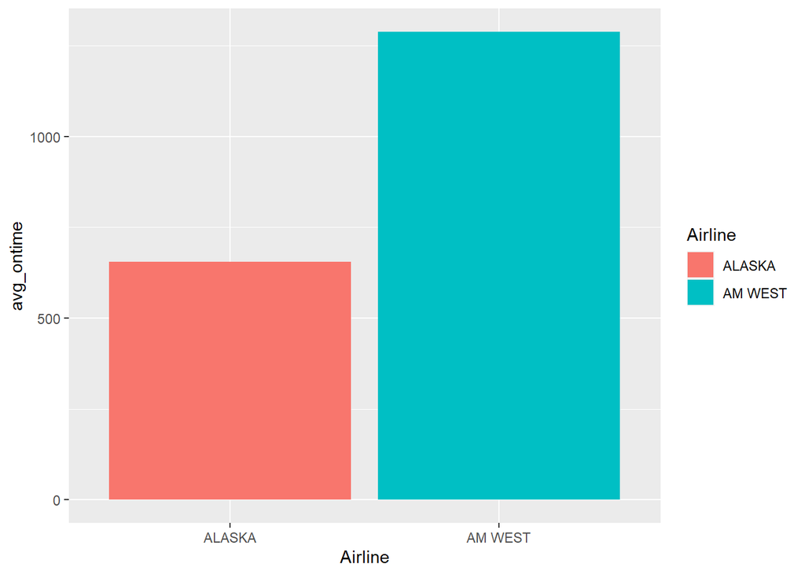

```r
ggplot(overall_ontime ,aes(x= Airline, y=avg_ontime, fill=Airline)) +
    geom_bar(stat="identity", position=position_dodge())
```

#### Calculate the per city ontime performance and comapre over plot

```r
percity_ontime <- transformed %>% group_by(Airline,City) %>% summarize(avg_ontime = mean(`on time`))
```

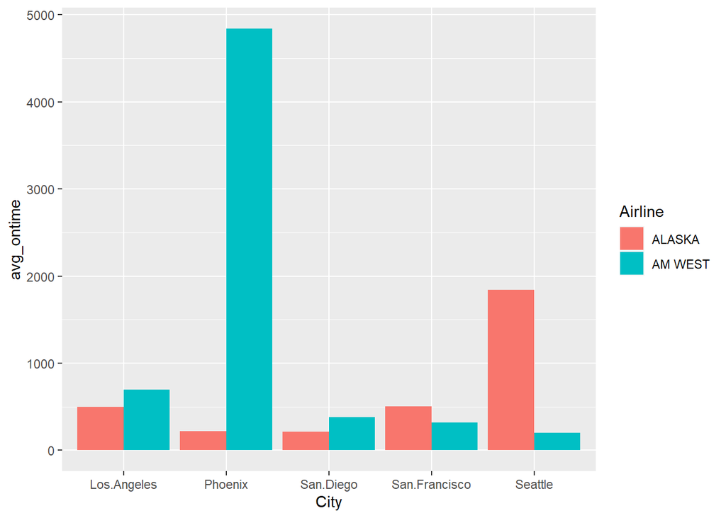

```r
ggplot(percity_ontime ,aes(x= City, y=avg_ontime, fill=Airline)) +
    geom_bar(stat="identity", position=position_dodge())
```

#### Calculate overall delay and compare over plot

```r
overall_delay <- transformed %>% group_by(Airline) %>% summarize(avg_delay = mean(`delayed`))
head(overall_delay)
```

```
## # A tibble: 2 x 2
##   Airline avg_delay
##   <chr>       <dbl>
## 1 ALASKA       100.
## 2 AM WEST      157.
```

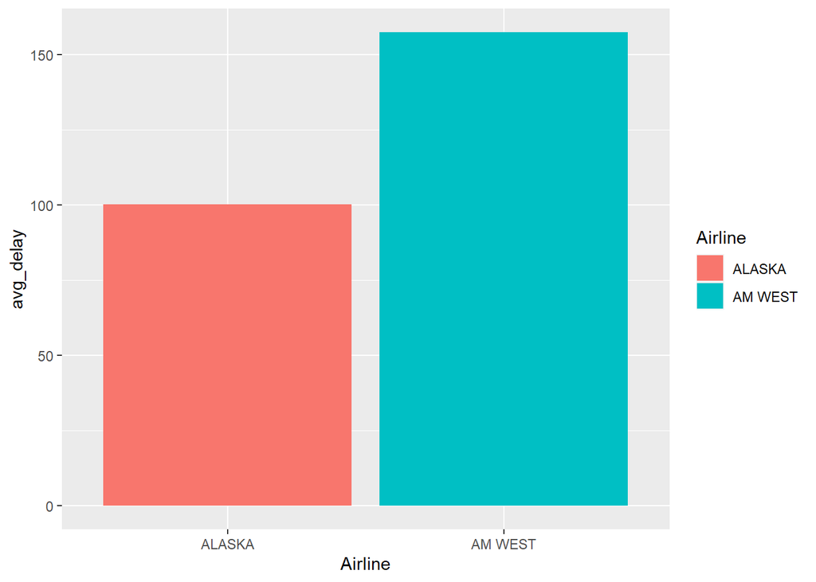

```r
ggplot(overall_delay ,aes(x= Airline, y=avg_delay, fill=Airline)) +
    geom_bar(stat="identity", position=position_dodge())
```

#### Calculate per-city delay and compare over plot

```r
percity_delay <- transformed %>% group_by(Airline,City) %>% summarize(avg_delay = mean(`delayed`))
head(percity_delay)
```

```
## # A tibble: 6 x 3
## # Groups:   Airline [2]
##   Airline City          avg_delay
##   <chr>   <chr>             <dbl>
## 1 ALASKA  Los.Angeles          62
## 2 ALASKA  Phoenix              12
## 3 ALASKA  San.Diego            20
## 4 ALASKA  San.Francisco       102
## 5 ALASKA  Seattle             305
## 6 AM WEST Los.Angeles         117
```

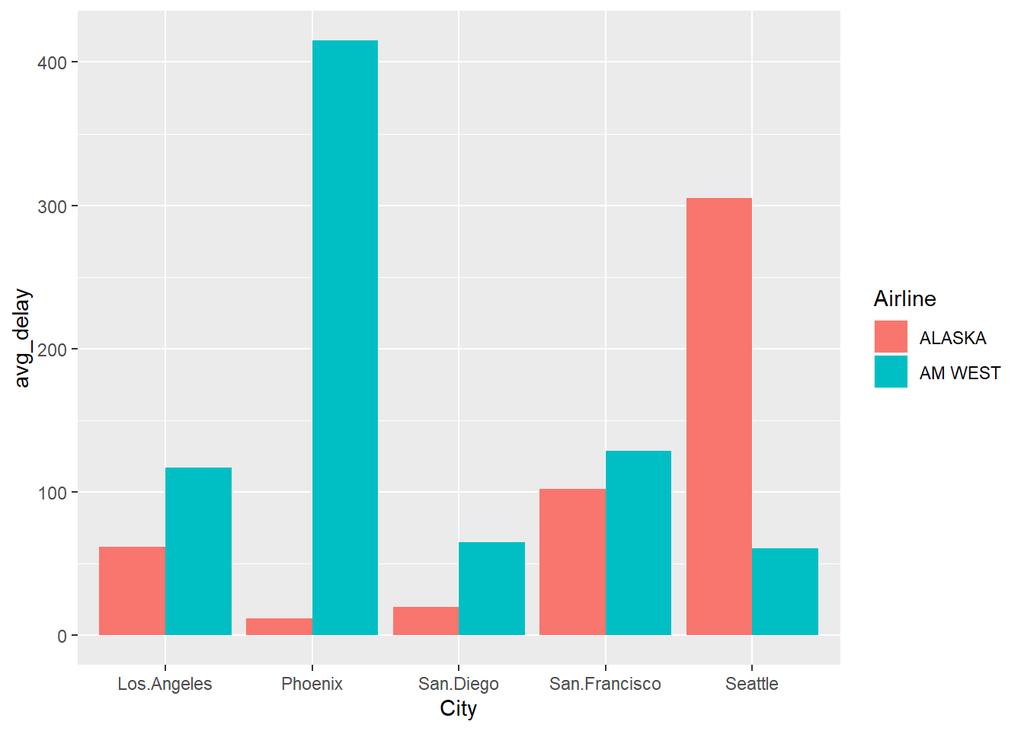

```r
ggplot(percity_delay ,aes(x= City, y=avg_delay, fill=Airline)) +
    geom_bar(stat="identity", position=position_dodge())
```

#### Conclusion

As per the overall performance graph, we see **AM WEST** has higher ontime flights compared to **ALSAKA** but when we see the same over per city performance, except two cities remaining cities have almost similar performance for both airlines. In city Seattle **ALSAKA** has higher ontime flights then **AM WEST**

When we compare the delay overview, **AM WEST** has higher delayed flights and comparing the ontime graph **AM WEST** has higher ontime flights - which contradicts to itself. This also means that higher ontime flights doesn’t guarantee lesser delay.